# Prosper Loan Data Exploration

## by Ahmed Khaled Mohamed Salah Abdelrahman

## Investigation Overview

> In our investigation through visualizations, we aim to look at the effect of some features to the amount of loan.

## Dataset Overview

> This dataset is a financial dataset and this is related to the loan, borrowers, lenders, interest rates and stuffs like that. Prosper or Prosper Marketplace Inc. is a San Francisco, California based company specializing in loans at low interest rates to the borrowers. In this dataset, we are using the data from the Posper to analyse it and trying to find the pattern in the Prosper data. [[*]](https://rstudio-pubs-static.s3.amazonaws.com/284488_195ef48d299e46f5b009987c8b988b69.html)

> Our data set contains 69K records and we focus on 13 features.

## Occupation

There are 68 occupations listed in the dataset. We will focus on the most common 25 ones. 'Professional' is the most common occupation among the borrowers with 11.6%. 'Executive', 'Administrative Assistant', and 'Teacher' comes next with about 4% each.

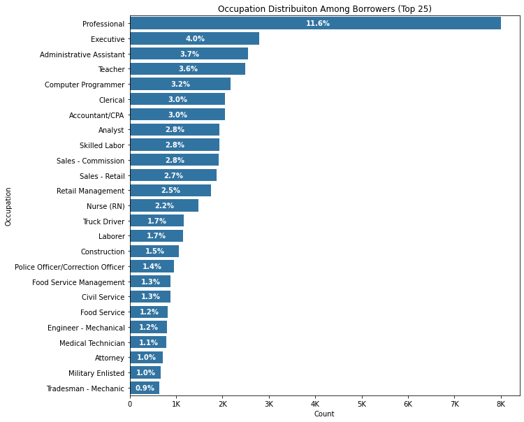

## Income

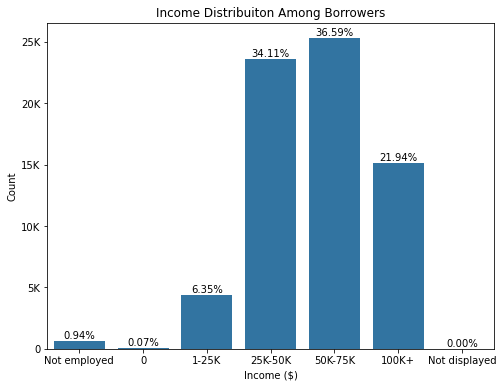

## Prosper Rating

The distribution of the prosper rating shows a uni-modal curve at the rating 4 with 21.5%. On both sides the curve tends to decrease until it reaches a tail at rating 1 with 8.76% and rating 7 with 5.93%. The middle values are ratings 3, 5, 6 with about 17% percent each. Rating 2 was given by Prosper to 12% of the borrowers.

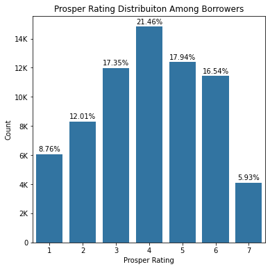

## Investors vs Loan Original Amount

A direct realtionship can be obtained between the number of investors and the original amount of loan. The majority of the borrowers who have more than 300 investors have got loans with amounts that surpass 15K \$.

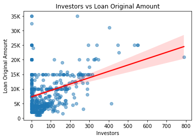

## Prosper Rating vs Loan Original Amount

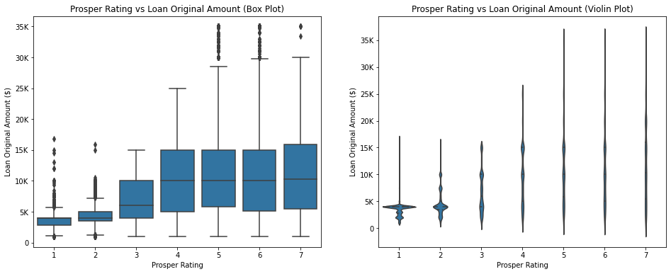

## Prosper Rating vs Investors

As seen, with higher prosper rating, a higher number investors the borrower get. Few borrowers got a rating of 7, but they still manage to attract more investors.

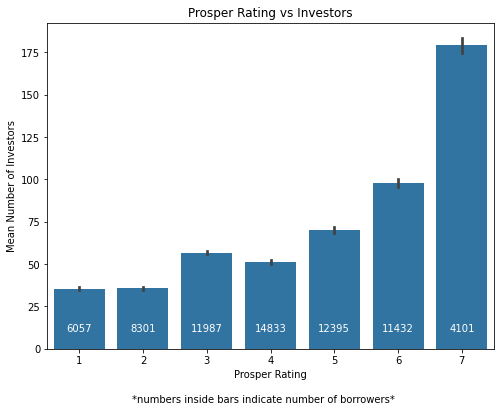

## Prosper Rating vs Investors vs Currently In Group

Having a higher Prosper rating helps you attract more investors, but combining the grade with working in a group helps you even more. With high ratings, the number of investors increases with the acknowledge of being in a group more than individually.

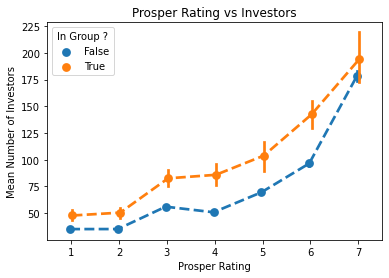

## Income vs Loan Original Amount vs Prosper Rating

Considering taking each Prosper rating separately, we can deduce that the amount change of the loan is higher with the change in the income level in the ratings of 4, 5, 6, and 7. The ratings of 1, 2, and 3 don't show that high gradient.

Surprisingly, A rating of 7 showed a lower mean of loan amount that lower ratings 5, and 6.

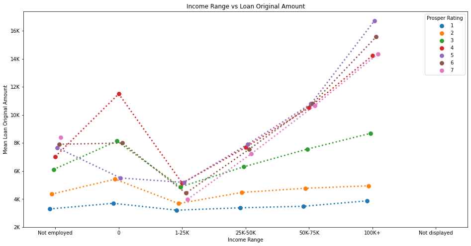